# Biblioteka calendR

Tymoteusz Kwieciński

2022-12-28

# Opis biblioteki *calendR*

Biblioteka *calendR* za pomocą pakietu ggplot2 umożliwia generowanie przejrzystych kalendarzy w bardzo prosty i szybki sposób.

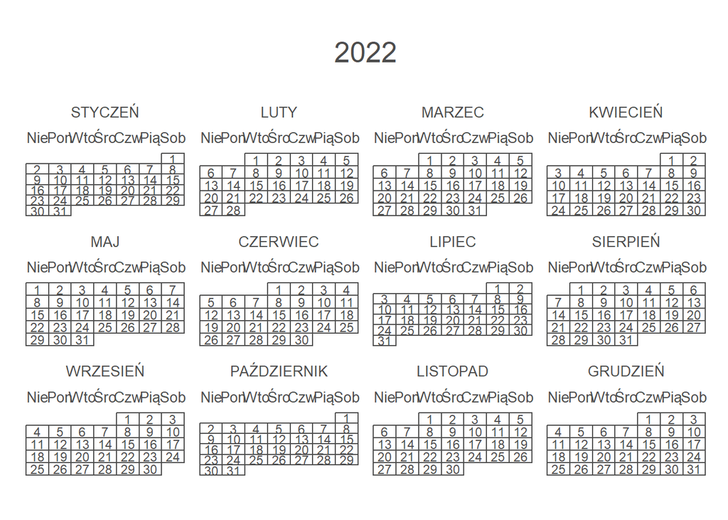

```r
library(calendR)
calendR()
```

Dostarcza ona jedną komendę o takiej samej nazwie jak pakiet - calendR(), która umożliwia generowanie kalendarza. Domyślnie komenda genereuje kalendarz na aktualny rok. Dostaracza bardzo wiele opcji modyfikowania otrzymanego kalendarza.

Jak widać, powyższy kalendarz nie wygląda zbyt dobrze w takim formacie. Można jednak edytować style powyższego kalendarza na różne sposoby:

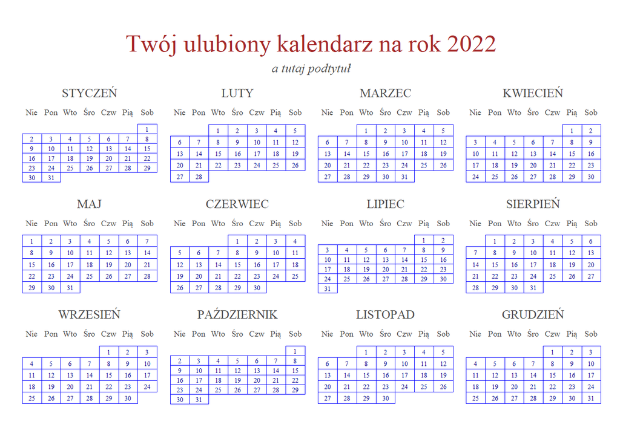

```r
calendR(font.family = "serif", # główna czcionka
        title = "Twój ulubiony kalendarz na rok 2022", # tytuł
        title.size = 20, # rozmiar czcionki tytułu
        title.col = "brown", # kolor tytułu
        subtitle = "a tutaj podtytuł", # podtytuł
        col = "blue", # kolor lini kalendarza
        lwd = 0.1, # szerokość lini kalendarza
        day.size = 2, # rozmiar czcionki dni
        days.col = "dark blue", # kolor numerów dni
        weeknames.size = 3 # rozmiar dni tygodnia
        )
```

Poza edycją stylów, które modyfikują wygląd naszego kalendarza, opisane jak wyżej, biblioteka dostarcza także różne sposoby wyświetlania kalendarza.

Rozpoczynając na modyfikacji, który dzień tygodnia rozpoczyna nasz kalendarz (opcja *start* przyjmująca wartości “M” oraz “S”, domyślnie ustawiona na “S”), przez wybieranie orientacji kalendarza (opcja *orientation* - “portrait” albo “landscape” - domyślna wartość), aż do wybierania okresu który chcemy przedstawić na kalendarzu.

Najbardziej podstawowy sposób wyboru czasu zaprezentowanego na kalendarzu to przy pomocy opcji *year* oraz *month*.

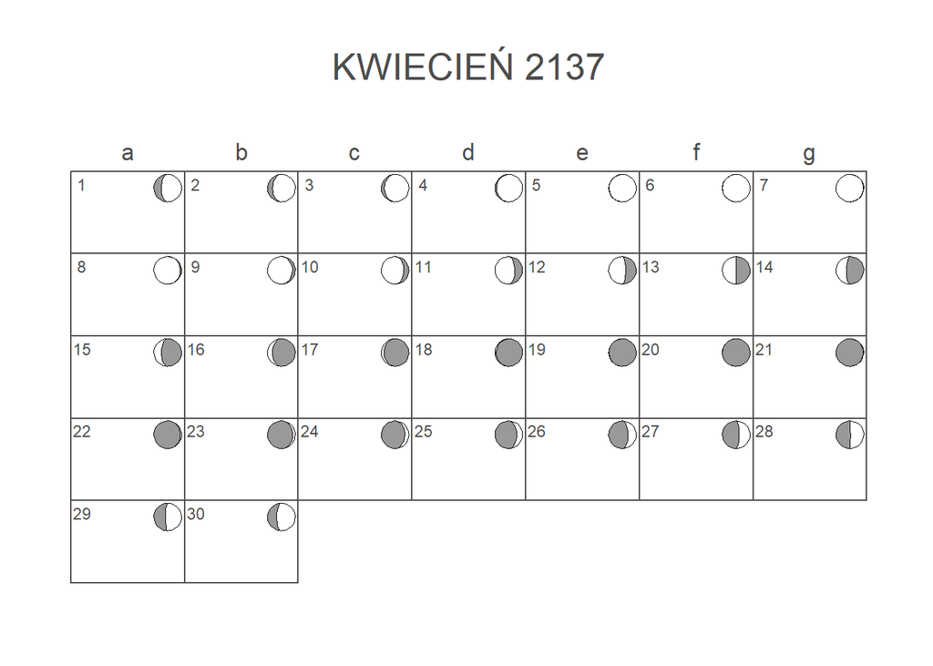

Aby uzyskać bardziej dokładne czasy można skorzystać z opcji *start_date* oraz *end_date*, które można podać zarówno w formie łańcucha znaków reprezentujących datę, np. *“2022-12-01* jak i jako zmienną reprezentującą datę.

```r
calendR(start_date = "2022-12-01",
        end_date = "2023-01-13",
        special.days = c(6, 9, 10), # dni które zostają pokolorowane
        special.col = "green",
        pdf = TRUE, # trzeba pamiętać, że jeżeli taki plik już istnieje to kod się wysypie
        doc_name = "nasz_kalendarz.pdf"
)
```

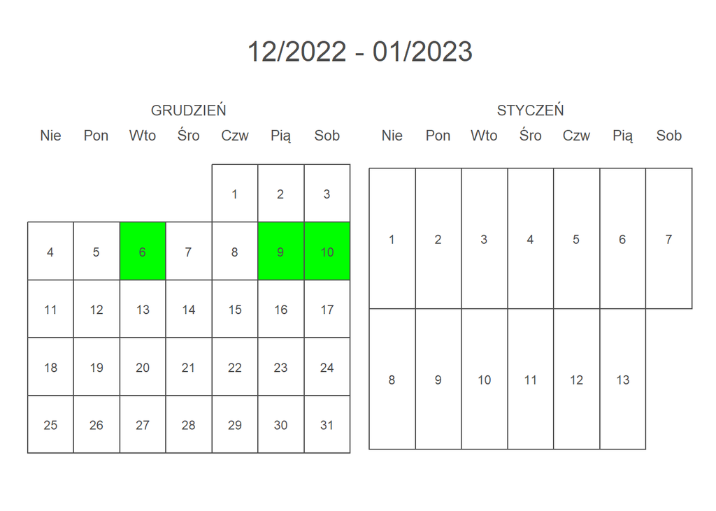

Na naszym kalendarzu możemy również zaznaczać i wyróżniać interesujące nas dni za pomocą koloru, a także zapisywać wygenerowany kalendarz do pliku pdf.

Jednak najbardziej interesującą moim zdaniem opcją funkcji generującej kalendarze, jest możliwość rysowania *heatmapy* na kalendarzu.

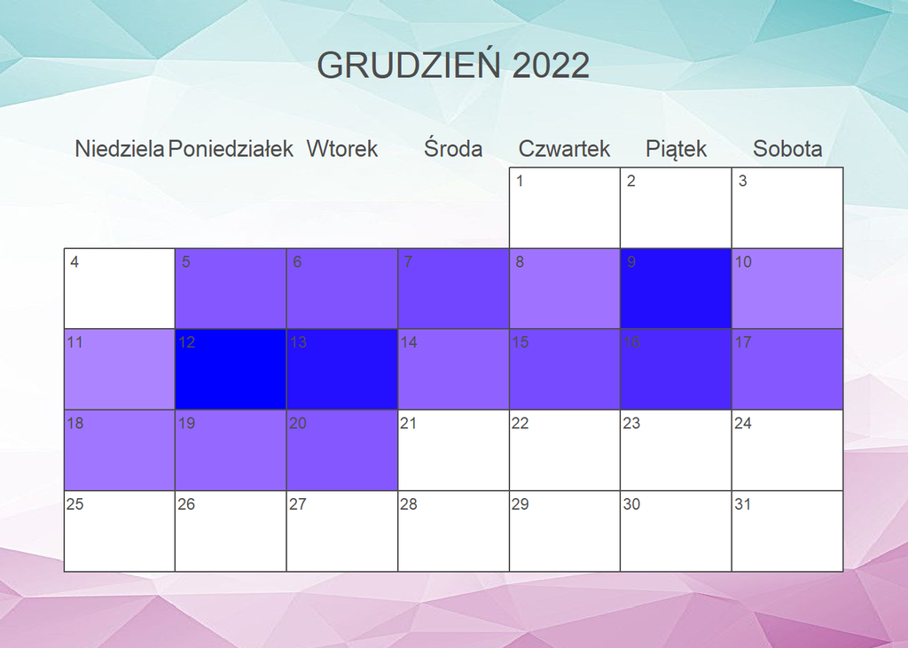

```r
days <- rep(0, 31) # generujemy wektor długości odpowiadającej liczbie dni

days[5:20] <- runif(16, 10, 20)

calendR(month = 12,
        special.days = days,
        special.col = "blue",
        gradient = TRUE,
        low.col = "white",
        bg.img = "https://i.pinimg.com/originals/10/1e/f6/101ef6a9e146b23de28fa2cd568ad17b.jpg") # obrazek na tło
```

Przekazując w odpowiedni sposób wektor zawierający dni, możemy pokolorować gradientem poszczególne dni - przydatne może być to do wizualizacji częstości pewnych zjawisk.